# stack_overflow_newTagCount

### Sample data analysis

**Question:** Can we predict the number of views or answers to a newly posted question on Stack Overflow based on:

- the reputation of the owner,
- popularity of post's tags.

**Reasoning:** It is reasonable to assume that a more distinguished user and/or a question on a "hot" topic may generate more interest. We want to verify this assumption, to test if we can use this information, which is available at the time when a question is posted, to predict the interest in the question.

**Data source:** Stack Overflow has an SQL based data explorer [online](https://data.stackexchange.com/stackoverflow/queries).

- Popular tags: first we count the number of post with a a given tag. Popularity of an area of interest may change. Therefore, we only assess posts within certain time bounds.

```
declare @startTime date = '2015-08-01'
declare @endTime date ='2015-10-01'

create table #Tags_Count (tagId int, tagCount int)
insert #Tags_Count
select
     PostTags.TagId,
     Count(*)
 from Posts
     inner join PostTags on PostTags.PostId = Posts.Id
 where  Posts.ParentId is null
   and Posts.CreationDate>=@startTime
   and Posts.CreationDate<@endTime
 group by PostTags.TagId
```

- Tags of a post: for a given post, we compute the number of tags, the frequency of the most popular post's tag, and the total number of posts which have at least on tag in common with the given post (incurs overcounting).

```
create table #Total_Tags_Count (postId int, numTags int, maxTagCount int, totalTagCount int)
insert #Total_Tags_Count
select
  Posts.Id,
  Count(*),
  Max(tagCount),
  Sum(tagCount)
from Posts
  inner join PostTags on PostTags.PostId = Posts.Id
  inner join #Tags_Count as tc on tc.tagId = PostTags.TagId
  where  Posts.ParentId is null
group by Posts.Id
```

- Post information: finally, we combine the information about tags of a post with other information about the post, such as score, number of views, number of answers and comments, and reputation of the user who posted the question

```
select
   Posts.Id,
   Posts.Score as postScore,
   Posts.ViewCount as views,
   Posts.AnswerCount as answers,
   Posts.CommentCount as comments,
   totalTagCount,
   maxTagCount,
   numTags,
   Users.Reputation as ownerRep
 from Posts
   inner join Users on Users.Id = Posts.OwnerUserId
   inner join  #Total_Tags_Count as ttc on ttc.postId = Posts.Id
 where  Posts.ParentId is null
 and Posts.CreationDate>=@startTime
 and Posts.CreationDate<@endTime
```

```python
import pandas as pd
import numpy as np
import matplotlib.pyplot as plt
import seaborn as sns
%matplotlib inline
```

```python
# import data
db = pd.read_csv('views_tagcount_tagnum_reputation_201508_201510_newTagCount.csv')
db.head() #verify if data is loaded
```

|  | Id | postScore | views | answers | comments | totalTagCount | maxTagCount | numTags | ownerRep |
| --- | --- | --- | --- | --- | --- | --- | --- | --- | --- |
| 0 | 32174274 | 4 | 116 | 3 | 4 | 29298 | 29055 | 2 | 5956 |
| 1 | 32167965 | 2 | 57 | 1 | 0 | 29055 | 29055 | 1 | 747 |
| 2 | 31826615 | 0 | 38 | 1 | 1 | 29851 | 20330 | 4 | 1 |
| 3 | 32554425 | 0 | 54 | 1 | 2 | 39883 | 38161 | 3 | 305 |
| 4 | 32182123 | -1 | 18 | 1 | 0 | 5660 | 4778 | 4 | 1 |

```python
db.isnull().values.sum() #check if there are any null values
```

```
0
```

```python
db.describe() # data stats
```

|  | Id | postScore | views | answers | comments | totalTagCount | maxTagCount | numTags | ownerRep |
| --- | --- | --- | --- | --- | --- | --- | --- | --- | --- |
| count | 50000.000000 | 50000.000000 | 50000.000000 | 50000.00000 | 50000.000000 | 50000.000000 | 50000.00000 | 50000.000000 | 50000.000000 |
| mean | 32316448.928700 | 0.452440 | 57.557780 | 1.10292 | 1.967520 | 26174.079680 | 20326.44630 | 3.013480 | 754.752440 |
| std | 323417.084549 | 1.898044 | 159.279243 | 0.98968 | 2.772706 | 23817.444129 | 16343.16089 | 1.219265 | 4478.732475 |
| min | 31756893.000000 | -14.000000 | 2.000000 | 0.00000 | 0.000000 | 1.000000 | 1.00000 | 1.000000 | 1.000000 |
| 25% | 32035669.500000 | 0.000000 | 26.000000 | 0.00000 | 0.000000 | 4736.000000 | 3451.00000 | 2.000000 | 11.000000 |
| 50% | 32318136.500000 | 0.000000 | 39.000000 | 1.00000 | 1.000000 | 24798.000000 | 20330.00000 | 3.000000 | 56.000000 |
| 75% | 32597171.250000 | 1.000000 | 58.000000 | 2.00000 | 3.000000 | 38210.000000 | 32646.00000 | 4.000000 | 355.000000 |
| max | 32877447.000000 | 126.000000 | 14302.000000 | 10.00000 | 48.000000 | 140964.000000 | 48492.00000 | 5.000000 | 398495.000000 |

By comparing means and medians, we can immediately see that "views" and "ownerRep" are very right skewed. We look into histograms and distributions of data in each column to decide on possible scaling.

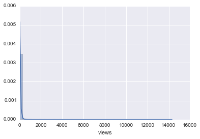

```python
# distribution of views
ax = sns.distplot(db.views)
```

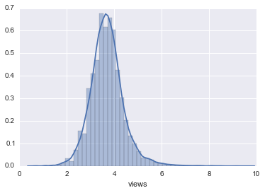

```python
ax = sns.distplot(np.log(db.views.astype('float64'))) ## log(views)
```

We start a new data frame in which the "views" are scaled using natural logarithm.

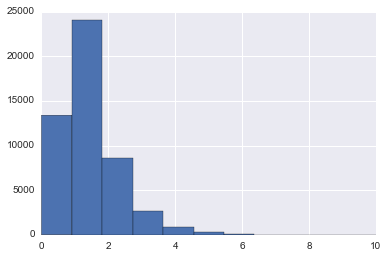

```python
# start a new data frame with modified variables
db2 = pd.DataFrame()
db2["log_views"] = np.log(db.views.astype('float64'))

### distribution of answers
array = plt.hist(db.answers, bins=11)
```

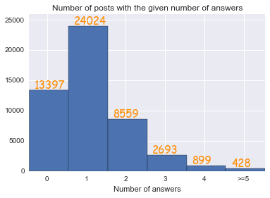

```python
db2['answers'] = db.answers
max_answers = 5 # category of 5 answers will mean that a post received at least 5 answers, to shorten the tail
db2.loc[db2.answers>max_answers, 'answers'] = max_answers

array = plt.hist(db2.answers, bins=range(max_answers+2))

fd = {'family':'fantasy', 'size':15, 'color':'darkorange'}
for i in range(max_answers+1):
    plt.text( array[1][i]+ (array[1][i+1]-array[1][i])*0.15, array[0][i]+300, '%d'%array[0][i], fontdict = fd)

plt.title('Number of posts with the given number of answers')
plt.xlabel('Number of answers')

plt.xlim(0, max_answers+1)
plt.ylim(0, max(array[0])+2000)

plt.xticks([0.45+i for i in range(max_answers+1)], ['%d'%i for i in range(max_answers)]+['>=%d'%max_answers])

plt.margins(0.2)
```

Every post with at least 5 answers is considered to have went "viral".

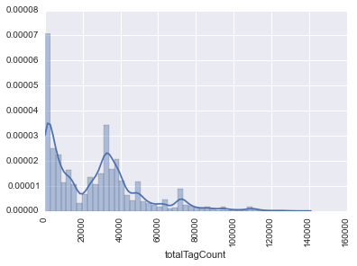

```python
ax = sns.distplot(db.totalTagCount)
locs, labels = plt.xticks(rotation=90) # rotate labels
```

There appears that values of "totalTagCount" fall within 4 ranges (categories).

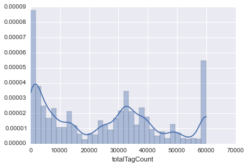

```python
db2['totalTagCount'] = db.totalTagCount
max_totTag = 60000 # to shorten the tail, we make a category of super-popular tags
db2.loc[db2.totalTagCount>max_totTag, 'totalTagCount'] = max_totTag
array = sns.distplot(db2.totalTagCount)
```

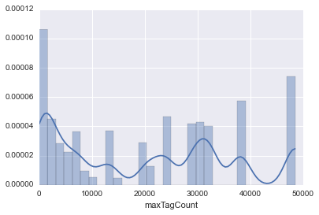

```python
ax = sns.distplot(db.maxTagCount)
db2['maxTagCount']=db.maxTagCount
```

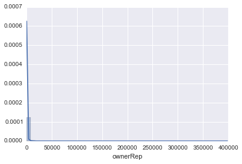

```python
ax = sns.distplot(db.ownerRep)
```

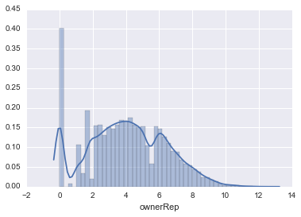

```python
ax = sns.distplot(np.log(db.ownerRep.astype('float64'))) ## log(views)
```

```python
db2['log_ownerRep']= np.log(db.ownerRep.astype('float64'))
db2['numTags'] = db.numTags

db2.head() # test that all is well
```

|  | log_views | answers | totalTagCount | maxTagCount | log_ownerRep | numTags |
| --- | --- | --- | --- | --- | --- | --- |
| 0 | 4.753590 | 3 | 29298 | 29055 | 8.692154 | 2 |
| 1 | 4.043051 | 1 | 29055 | 29055 | 6.616065 | 1 |
| 2 | 3.637586 | 1 | 29851 | 20330 | 0.000000 | 4 |
| 3 | 3.988984 | 1 | 39883 | 38161 | 5.720312 | 3 |
| 4 | 2.890372 | 1 | 5660 | 4778 | 0.000000 | 4 |

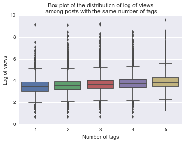

```python
ax = sns.boxplot(x="numTags", y="log_views", data=db2, order=[1,2,3,4,5])
t = plt.title('Box plot of the distribution of log of views\n among posts with the same number of tags')
xl = plt.xlabel('Number of tags')
yl = plt.ylabel('Log of views')
```

The distributions of log of views among posts with the same number of tags have the following properties: they have many outlier, but relatively constant variability and means and medians are close. There seems to be some correlation between the number of tags and the mean log of views, as means slightly increase with increase of the number of tags.

Next we make a scatter plot. The coordinates of each point are log of reputation of the post's owner and total frequency of tags of the post. The colour represents if there is at least one answer for the post (blue) or if the post has not been answered (red).

```
the number of post with no answer / number of posts = 13397 / 50000
```

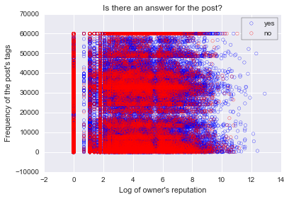

```python
db3 = db2

no_answer = db3.answers==0
print 'the number of post with no answer / number of posts =', no_answer.values.sum(), '/', db3.shape[0]

plt.scatter(x=db3.log_ownerRep[~no_answer], y=db3.totalTagCount[~no_answer], marker='o', facecolors='none', edgecolors='b', label='yes')
plt.scatter(x=db3.log_ownerRep[no_answer], y=db3.totalTagCount[no_answer], marker='o', facecolors='none', edgecolors='r', label='no')
plt.title('Is there an answer for the post?')
plt.xlabel('Log of owner\'s reputation')
plt.ylabel('Frequency of the post\'s tags')
leg = plt.legend(frameon=True, loc=0) #frame and location of the legend
leg.get_frame().set_edgecolor('k')
```

To make this figure less cluttered, we present some random subset of points.

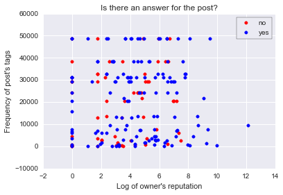

```python
num_rows = db2.shape[0]
num_examples = 200
rand_rows = np.random.randint(0,num_rows,num_examples) # get random 150 points (with possible repetitions)

db3 = db2.loc[rand_rows, :]

no_answer = db3.answers==0

plt.scatter(x=db3.log_ownerRep[no_answer], y=db3.maxTagCount[no_answer], marker='o', color = 'r', label='no')
plt.scatter(x=db3.log_ownerRep[~no_answer], y=db3.maxTagCount[~no_answer], marker='o', color='b', label='yes')
plt.title('Is there an answer for the post?')
plt.xlabel('Log of owner\'s reputation')
plt.ylabel('Frequency of post\'s tags')
leg = plt.legend(frameon=True, loc=0) # frame and location of the legend
leg.get_frame().set_edgecolor('k')
```

Scatter plot did not provide much information. Next, we want to make several heat plots. The following function takes in as input variables:

- a database,
- two explanatory variables and one response variable,
- number of bins for each of explanatory variables,
- a function which is to be applied on data.

The function splits the explanatory variables into mutually disjoint, exhaustive, equal length intervals, whose number is given on input, to produce two dimensional bins. Then it groups the responses into these bins and applies a given function on data in each bin. It records the output in a matrix.

```python
# prepare matrix for heat plot
def get_matrix(db, x,y,response, func, x_numbins, y_numbins):
    mat = [[0 for i in range(x_numbins)] for j in range(y_numbins)] #output matrix

    # determine interval length and bounds
    xstep = float(max(db[x])-min(db[x]))/x_numbins
    xbounds=[min(db[x])+i*xstep for i in range(x_numbins+1)]
    ystep = float(max(db[y])-min(db[y]))/y_numbins
    ybounds=[min(db[y])+j*ystep for j in range(y_numbins+1)]

    # group response variable in bins
    for i in range(x_numbins):
        for j in range(y_numbins):
            ans = db[response][ (db[x]>=xbounds[i]) & (db[x]<xbounds[i+1]) & (db[y]>=ybounds[j]) & (db[y]<ybounds[j+1])]
            if ans.shape[0]>0: # if there are any answers in this category, apply the function to it
                mat[y_numbins-1-j][i] = func(ans)
    return [mat,xbounds,ybounds]
```

Now, we will use this function to plot mean and median of the logarithm of views for posts which have total frequency of their tags and the log of owner's reputation within given bounds. We also count the number of posts in these categories.

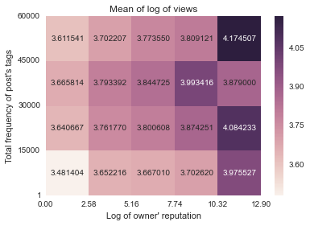

```python
xbins = 5
ybins = 4
mat1,xbounds,ybounds = get_matrix(db2, 'log_ownerRep','totalTagCount',  'log_views', np.mean, xbins,ybins)
ax1 = sns.heatmap(mat1, annot=True, fmt='f')

plt.title('Mean of log of views')
plt.xlabel('Log of owner\' reputation')
plt.ylabel('Total frequency of post\'s tags')

xlabels = ['%.2f'%xbounds[i] for i in range(xbins+1)] # format x-axis labels
plt.xticks(range(xbins+1), xlabels, rotation=0)
ylabels = ['%.d'%ybounds[i] for i in range(ybins+1)] # y-axis labels
plt.yticks(range(ybins+1), ylabels, rotation=0)

plt.margins(0.2)
#plt.subplots_adjust(bottom=0.15) # spacing at the bottom
```

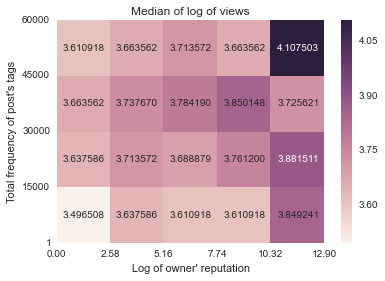

```python
xbins = 5
ybins = 4

mat2,xbounds,ybounds = get_matrix(db2, 'log_ownerRep',  'totalTagCount', 'log_views', np.median, xbins, ybins)
ax = sns.heatmap(mat2, annot=True, fmt='f')

plt.title('Median of log of views')
plt.xlabel('Log of owner\' reputation')
plt.ylabel('Total frequency of post\'s tags')

xlabels = ['%.2f'%xbounds[i] for i in range(xbins+1)] # format x-axis labels
plt.xticks(range(xbins+1), xlabels, rotation=0)
ylabels = ['%.d'%ybounds[i] for i in range(ybins+1)] # y-axis labels
plt.yticks(range(ybins+1), ylabels, rotation=0)

plt.margins(0.2)
```

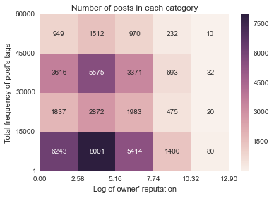

```python
xbins = 5
ybins = 4

mat3,xbounds,ybounds = get_matrix(db2, 'log_ownerRep', 'totalTagCount', 'log_views', len, xbins, ybins)
ax = sns.heatmap(mat3, annot=True, fmt='d')

plt.title('Number of posts in each category')
plt.xlabel('Log of owner\' reputation')
plt.ylabel('Total frequency of post\'s tags')

xlabels = ['%.2f'%xbounds[i] for i in range(xbins+1)] # format x-axis labels
plt.xticks(range(xbins+1), xlabels, rotation=0)
ylabels = ['%.d'%ybounds[i] for i in range(ybins+1)] # y-axis labels
plt.yticks(range(ybins+1), ylabels, rotation=0)

plt.margins(0.2)
```

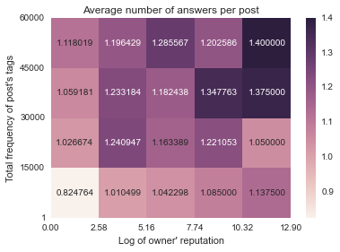

```python
xbins = 5
ybins = 4

mat4,xbounds,ybounds = get_matrix(db2, 'log_ownerRep', 'totalTagCount', 'answers', np.mean, 5, 4)
ax = sns.heatmap(mat4, annot=True, fmt='f')

plt.title('Average number of answers per post')
plt.xlabel('Log of owner\' reputation')
plt.ylabel('Total frequency of post\'s tags')

xlabels = ['%.2f'%xbounds[i] for i in range(xbins+1)] # format x-axis labels
plt.xticks(range(xbins+1), xlabels, rotation=0)
ylabels = ['%.d'%ybounds[i] for i in range(ybins+1)] # y-axis labels
plt.yticks(range(ybins+1), ylabels, rotation=0)

plt.margins(0.2)
```

**Idea for improvement:** Make all tags of proportional weight by dividing tag frequences by the most frequent tag. Then, each tag will contribute at most 1 to the total tag count, which may be a better predictor.